# Normal Area

Alan T. Arnholt

Last compiled: Sunday, October 30, 2016 - 16:18:22.

# 1 Shading a Subregion Under a Function Curve

Note: The material in Section 1 is modified from Chang (2013).

## Problem

You want to shade part of the area under a function curve.

## Solution

Define a new wrapper function around your curve function, and replace out-of-range values with `NA`, as shown in Figure 1.1:

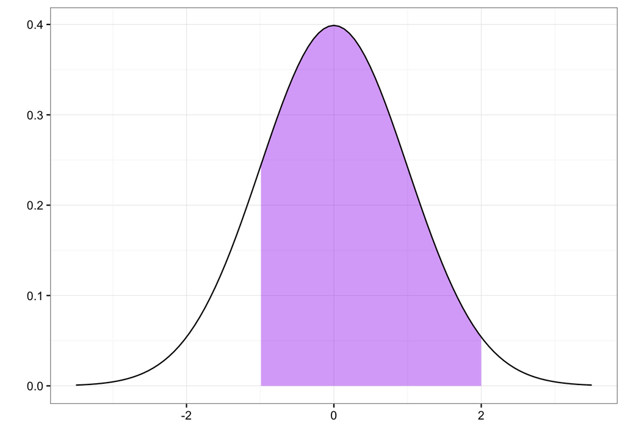

Figure 1.1: Function curve with a shaded region

```r
# Return dnorm(x) for -1 < x < 2, and NA for all other x
dnorm_limit <- function(x) {
  y <- dnorm(x)
  y[x < -1 | x > 2] <- NA
  return(y)
}
# ggplot() with dummy data
p <- ggplot(data.frame(x=c(-3.5, 3.5)), aes(x = x))
p + stat_function(fun = dnorm_limit, geom = "area", fill = "purple", alpha = 0.4, n = 500) +
  stat_function(fun = dnorm) +
  theme_bw() +
  labs(x = "", y = "")
```

Remember that what gets passed to this function is a vector, not individual values. If this function operated on single elements at a time, it might make sense to use an if/else statement to decide what to return, conditional on the value of `x`. But that won’t work here, since `x` is a vector with many values.

## Discussion

R has first-class functions, and we can write a function that returns a closure—that is, we can program a function to program another function. This function will allow you to pass in a function, a minimum value, and a maximum value. Values outside the range will again be returned with `NA`:

```r
limitRange <- function(fun, min, max) {
  function(x) {
    y <- fun(x)
    y[x < min | x > max] <- NA
    return(y)
  }
}
```

Now we can call this function to create another function—one that is effectively the same as the `dnorm_limit()` function used earlier:

```r
# This returns a function
dlimit <- limitRange(dnorm, -1, 2)
# Now we'll try out the new function -- it only returns values for inputs
# between -1 and 2
dlimit(-2:4)
```

```
[1]         NA 0.24197072 0.39894228 0.24197072 0.05399097         NA
[7]         NA
```

We can use `limitRange()` to create a function that is passed to `stat_function()`:

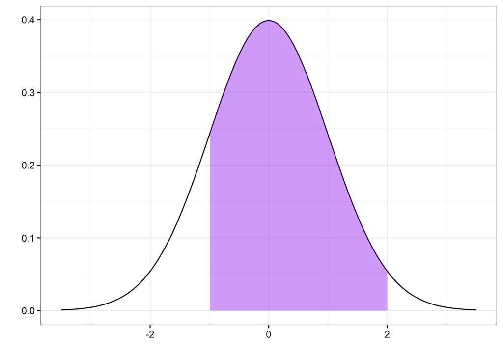

```r
p + stat_function(fun = dnorm) +
  stat_function(fun = limitRange(dnorm, -1, 2),
                geom = "area", fill = "purple", alpha = 0.4, n = 500) +
  theme_bw() +
  labs(x = "", y = "")
```

# 2 One Function Now

```r
areabetweenN <- function(mu = 0, sigma = 1, min = -1, max = 1){
  abN <- round(pnorm(max, mu, sigma) - pnorm(min, mu, sigma),4)
  p <- ggplot(data.frame(x=c(mu - 3.5*sigma, mu + 3.5*sigma)), aes(x = x))
  limitRange <- function(min = min, max = max) {
    function(x) {
      y <- dnorm(x, mu, sigma)
      y[x < min | x > max] <- NA
      return(y)
    }
  }
  p + stat_function(fun = dnorm, args = list(mu, sigma)) +
    stat_function(fun = limitRange(min = min, max = max),
                  geom = "area", fill = "purple", alpha = 0.4, n = 500) +
    theme_bw() +
    labs(x = "", y = "", title = paste("The area between", min, "and", max, "is", abN))
}
```

Given $X\sim N(100, 15)$, draw the area between 85 and 115.

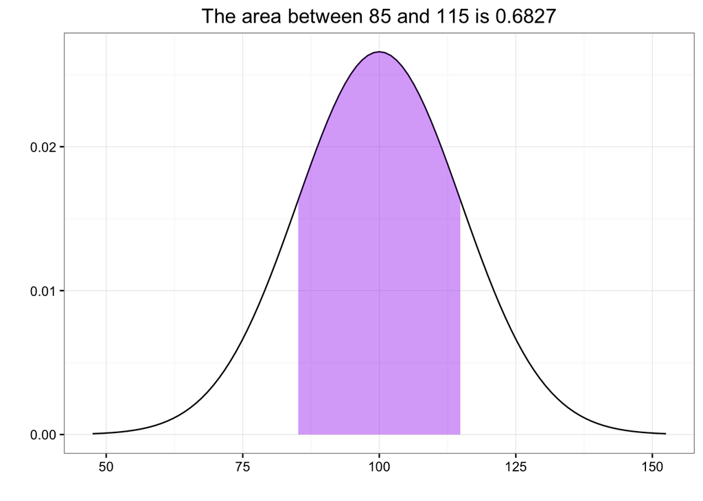

```r
areabetweenN(100, 15, 85, 115)
```

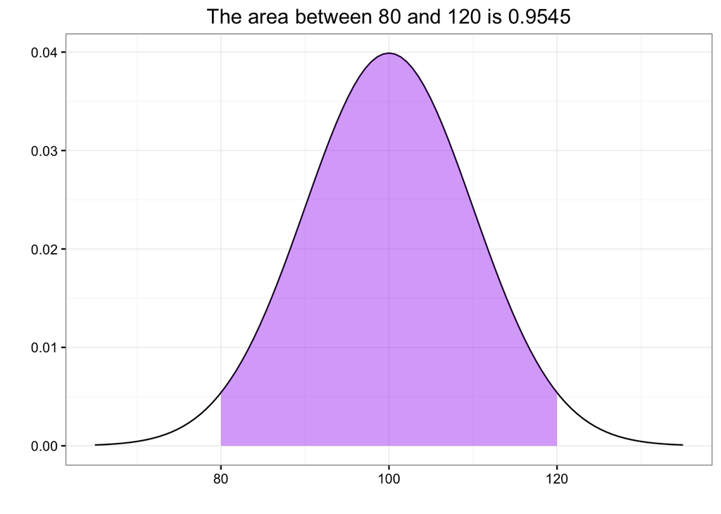

```r
areabetweenN(100, 10, 80, 120)
```

## 2.1 Showing the Standard Deviations

```r
areabetweenN <- function(mu = 0, sigma = 1, min = -1, max = 1, ALPHA = 0.4, FILL = "PURPLE"){
  abN <- round(pnorm(max, mu, sigma) - pnorm(min, mu, sigma),4)
  p <- ggplot(data.frame(x=c(mu - 3.5*sigma, mu + 3.5*sigma)), aes(x = x))
  limitRange <- function(min = min, max = max) {
    function(x) {
      y <- dnorm(x, mu, sigma)
      y[x < min | x > max] <- NA
      return(y)
    }
  }
  SDB <- -3:3*sigma + mu
  p + stat_function(fun = dnorm, args = list(mu, sigma)) +
    stat_function(fun = limitRange(min = min, max = max),
                  geom = "area", fill = FILL, alpha = ALPHA, n = 500) +
    theme_bw() +
    labs(x = paste("X ~ N(", mu,",",sigma,")"), y = "", title = paste("The area between", min, "and", max, "is", abN)) +
    scale_x_continuous(breaks=SDB)
}
```

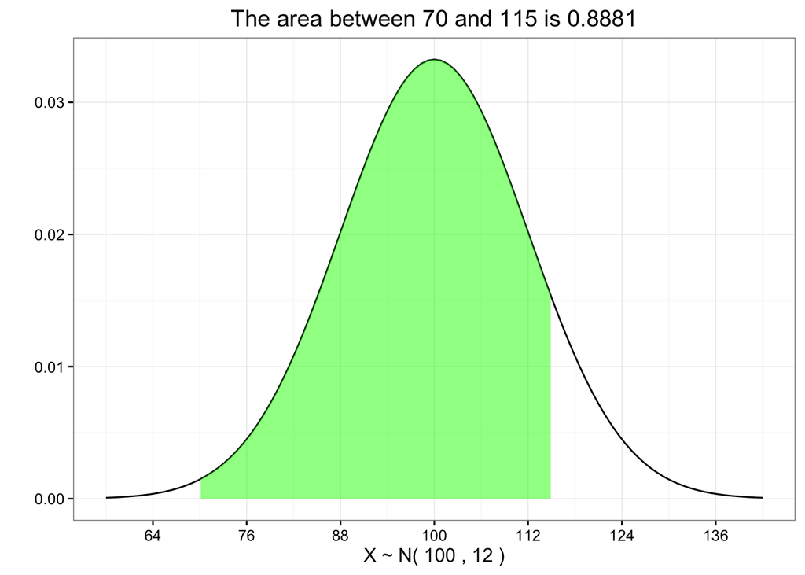

```r
areabetweenN(100, 12, 70, 115, FILL = "green", ALPHA = 0.5)
```

## 2.2 Embedding a Shiny App

```r
ui <- fluidPage(
  # Application title
  titlePanel("Area Between Two Values of A Normal Distribution"),
  sidebarLayout(
    sidebarPanel(
      numericInput(inputId = "MU", label = "Mean:", value = 0, min = -Inf, max = Inf),
      numericInput(inputId = "SIGMA", label = "Standard Deviation:", value = 1, min = 0.0000001, max = Inf),
      numericInput(inputId = "MIN", label = "Lower:", value = -2, min = -Inf, max = Inf),
      numericInput(inputId = "MAX", label = "Upper:", value = 2, min = -Inf, max = Inf),
      textInput(inputId = "COLOR", label = "Color:", value = "hotpink"),
      numericInput(inputId = "ALPHA", label = "Intensity:", value = 0.4, min = 0.05, max = 1)
    ),
    mainPanel(
      plotOutput("NG", height = "500px", width = "500px")
    )
  ))


server <- function(input, output){
  library(ggplot2)
  output$NG <- renderPlot({
    abN <- round(pnorm(input$MAX, input$MU, input$SIGMA) - pnorm(input$MIN, input$MU, input$SIGMA),4)
    p <- ggplot(data.frame(x=c(input$MU - 3.5*input$SIGMA, input$MU + 3.5*input$SIGMA)), aes(x = x))
    limitRange <- function(min = input$MIN, max = input$MAX) {
      function(x) {
        y <- dnorm(x, input$MU, input$SIGMA)
        y[x < input$MIN | x > input$MAX] <- NA
        return(y)
      }
    }
    SDB <- -3:3*input$SIGMA + input$MU
    p + stat_function(fun = dnorm, args = list(input$MU, input$SIGMA)) +
      stat_function(fun = limitRange(min = input$MIN, max = input$MAX),
                    geom = "area", fill = input$COLOR, alpha = input$ALPHA, n = 500) +
      theme_bw(base_size = 18) +
      labs(x = paste("X ~ N(", input$MU,",",input$SIGMA,")"), y = "", title = paste("The area between", input$MIN, "and", input$MAX, "is", abN)) +
      scale_x_continuous(breaks=SDB)
  })
}
shinyApp(ui = ui, server = server, options = list(height = 580))
```

[interactive chart not shown]

To run the app directly from the server, click on https://alanarnholt.shinyapps.io/Normal_Area/.

## References

Chang, Winston. 2013. *R Graphics Cookbook: [Practical Recipes for Visualizing Data]*. 1. ed. Beijing: O’Reilly.